# Exercise - ‘IzpitR1’

В задачи 1, 2 и 3 се използват данните ’Aids2’ от пакета ” MASS“.

|  | state | sex | diag | death | status | T.categ | age |
| --- | --- | --- | --- | --- | --- | --- | --- |
| 1 | NSW | M | 10905 | 11081 | D | hs | 35 |
| 2 | NSW | M | 11029 | 11096 | D | hs | 53 |
| 3 | NSW | M | 9551 | 9983 | D | hs | 42 |
| 4 | NSW | M | 9577 | 9654 | D | haem | 44 |
| 5 | NSW | M | 10015 | 10290 | D | hs | 39 |
| 6 | NSW | M | 9971 | 10344 | D | hs | 36 |
| 7 | NSW | M | 10746 | 11135 | D | other | 36 |
| 8 | NSW | M | 10042 | 11069 | D | hs | 31 |
| 9 | NSW | M | 10464 | 10956 | D | hs | 26 |
| 10 | NSW | M | 10439 | 10873 | D | hsid | 27 |

[output cut: 990 more lines]

1 zad. Колко от изследваните са на възраст под 20 години? • Определете пола на първите петима диагностицирани със спин. • Каква част от мъжете са се заразили по кръвен път (blood)? • Направете подходяща графика, която да отразява връзката на смъртността и щатът, в който живеят пациентите.

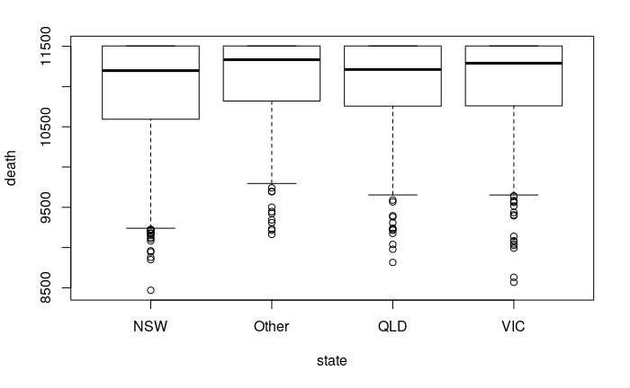

2 zad. Вярно ли е, че при жените смъртността е по-ниска? Формулирайте и проверете хипотеза за това твърдение.

```r
t.test(women, men, alternative = 'less')
```

```
    Welch Two Sample t-test

data:  women and men
t = -1.4005, df = 91.99, p-value = 0.08236
alternative hypothesis: true difference in means is less than 0
95 percent confidence interval:
     -Inf 20.85629
sample estimates:
mean of x mean of y
 10881.87  10993.76
```

3 zad. Можем ли да приемем, че средната възраст на починалите пациенти е 38 години?

```r
t.test(ageDead-38)
```

```
    One Sample t-test

data:  ageDead - 38
t = -0.83886, df = 1760, p-value = 0.4017
alternative hypothesis: true mean is not equal to 0
95 percent confidence interval:
 -0.6899803  0.2765789
sample estimates:
 mean of x
-0.2067007
```

4 zad. Нека X е случайна величина с хи-квадрат разпределение с 10 степени на свобода. Генерирайте 100 наблюдения над X и по тях постройте хистограма. На същата графика начертайте теоретичната функция на плътността на X.

```
NaNs produced
```

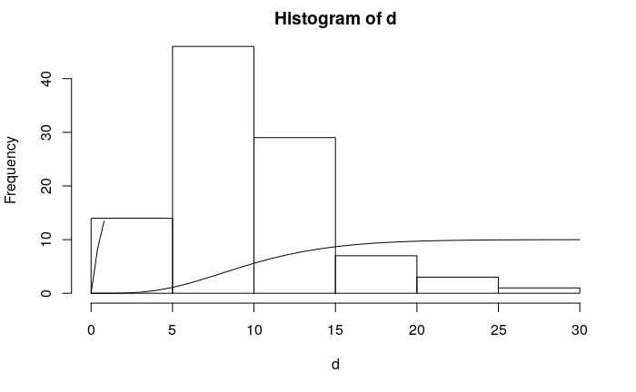

```r
d = rchisq(100, 10)
hist(d)
id = function (x) x
x = 0:30
lines(x, pchisq(x, 10)*10) # ???
curve(qchisq(x, 10), from = 0, to = 40, add = TRUE)
```

5 zad. Използвайте наблюденията само за мъжките котки от данните ”cats“ в пакета MASS. Как зависи теглото на сърцето от общото тегло? Вярно ли е, че при котки по тежки с 1 кг сърцето е по тежко с 5 гр? Постройте 95% доверителен интервал за сърцето на котка, с тегло 2.6 кг.

```r
t.test((Hwt+0.23)/Bwt-5, conf.level=0.95)
```

```
    One Sample t-test

data:  (Hwt + 0.23)/Bwt - 5
t = -23.072, df = 143, p-value < 2.2e-16
alternative hypothesis: true mean is not equal to 0
95 percent confidence interval:
 -1.0983574 -0.9250091
sample estimates:
mean of x
-1.011683
```

6 zad. Три групи от по 20 жени са спазвали три различни диети. В ”Data1.txt“ са дадени килограмите, с който са отслабнали жените. Представете данните графично. Диетите различават ли се съществено?

```r
data = scan(file="Data1.txt")
```

```
Error in scan(file = "Data1.txt") :
  scan() expected 'a real', got '"x1";"x2";"x3"'
```